# Explanatory Data Analysis

### By Muhammed Jimoh

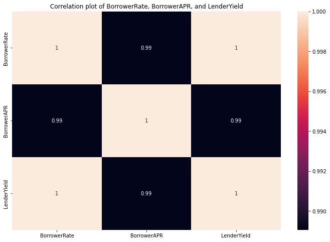

The following variables/features are strongly correlated:

```
    BorrowerRate, BorrowerAPR, and LenderYield
```

Hence, I will be using BorrowerAPR to represent the other two, though correlation doesn't necessary implies causation.

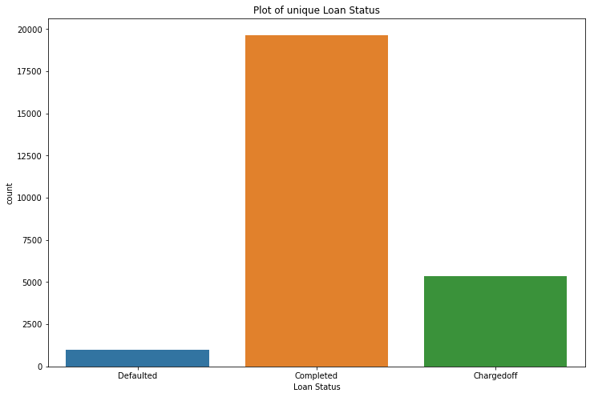

- Yes, the dataset is imbalanced with over one-third of the datset belonging to *Completed*.
- **Completed:** 75.6%, **Chargedoff: 20.53%** and **Defaulted: 3.87%**

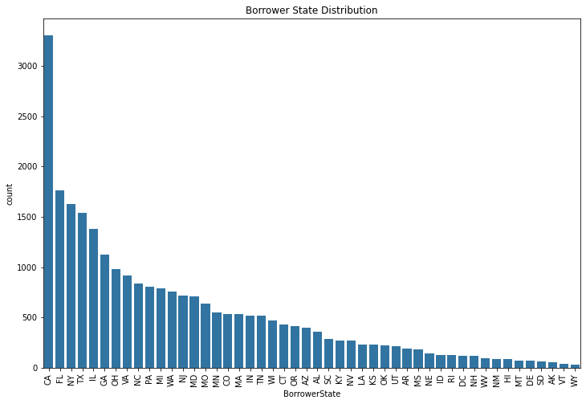

- The top five states borrowers reside in are: **CA, FL, NY, TX and IL**

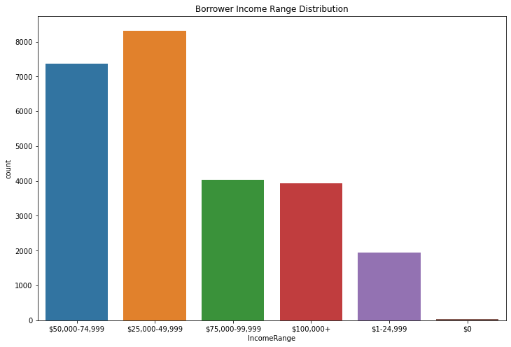

- The top two income brackets for borrowers are: **25,000 USD - 49,000 USD, and 50,000 USD - 74,999 USD**

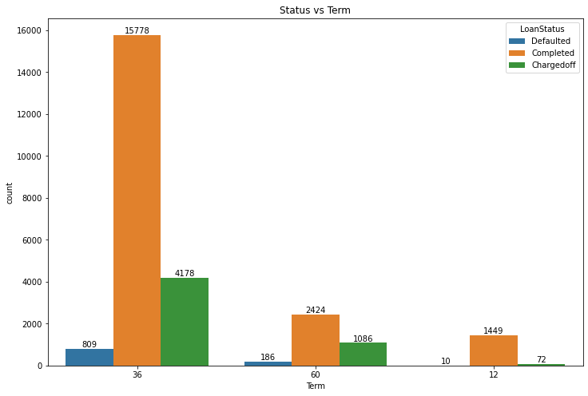

- The 36 months loan term had the highest number of values as expected since the data is imbalanced.
- Most tend to default on the 60 months loan as it is a long term loan.
- Alos, the 60 months loan term have a significant amount of chargedoff as compared to others

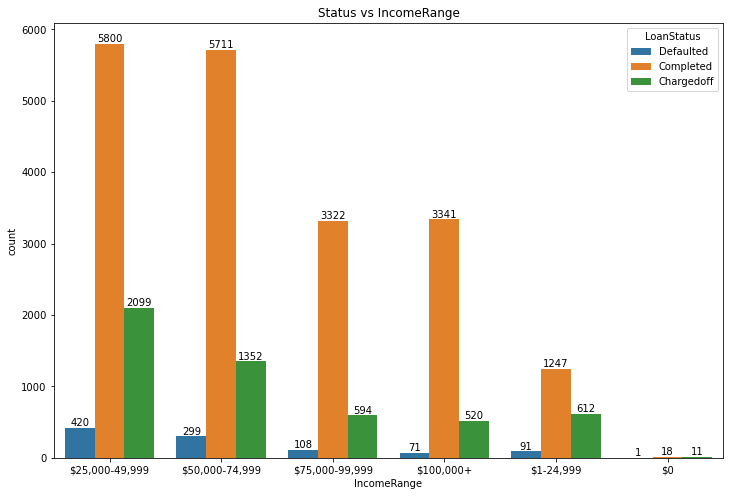

- People in the **25,000 USD - 49,000 USD, and 50,000 USD - 74,999 USD** tend to borrow a lot.
- People in the **1 USD - 24,000 USD** default on loans alot, and have a significant amount of chargedoff.
- People with IncomeRange greater than or equal to 25,000 USD had the highest count in terms of loan consideration. With majority being around 25,000 USD - 74,999 USD

**ListingCategory:** (Nominal Variable)

- The category of the listing that the borrower selected when posting their listing:

  0 - Not Available, 1 - Debt Consolidation, 2 - Home Improvement, 3 - Business, 4 - Personal Loan, 5 - Student Use, 6 - Auto, 7- Other, 8 - Baby&Adoption, 9 - Boat, 10 - Cosmetic Procedure, 11 - Engagement Ring, 12 - Green Loans, 13 - Household Expenses, 14 - Large Purchases, 15 - Medical/Dental, 16 - Motorcycle, 17 - RV, 18 - Taxes, 19 - Vacation,20 - Wedding Loans,

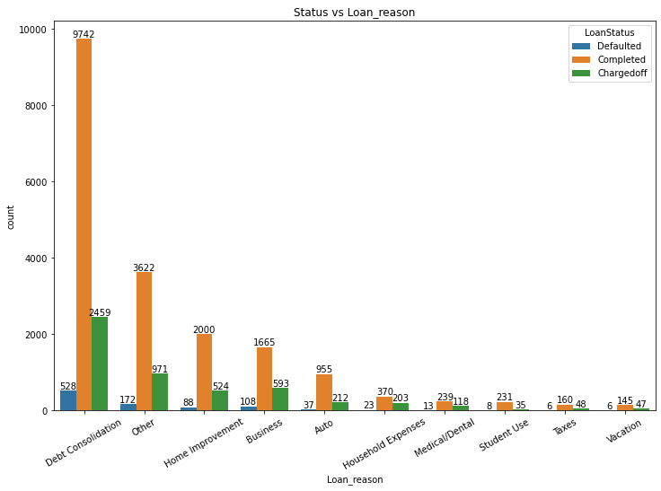

- Most people's reason for borrowing loan is due to **Debt Consolidation**
- Majority of the defaulters had oustanding debt already.

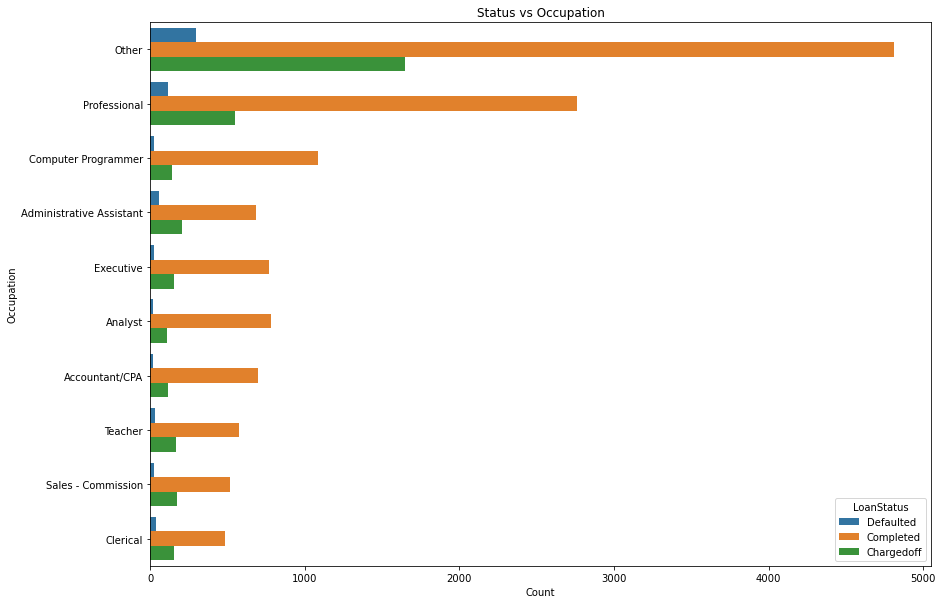

- The major two occupation of borrowers are **Other, and Professional**

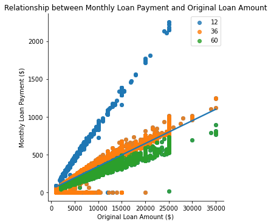

- The relationship between MonthlyLoanPayment and LoanOriginalAmount is a positive and increasing relationship, though the slope is steeper for different types of term.

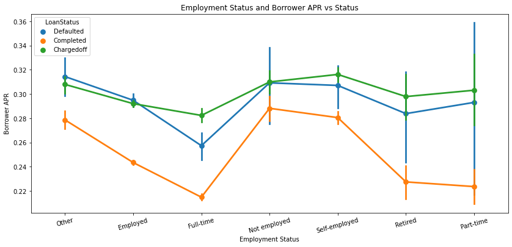

- Most people tend to default on a loan with higher BorrowerAPR as compared to loans with lower BorrowerApr regardless of their employement status.

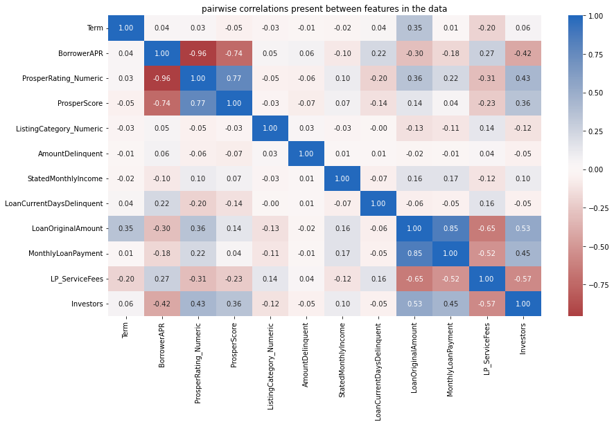

- The following pairs of variables are strongly positively correlated:

  ```
    [MonthlyLoanPayment, LoanOriginalAmount], [ProsperScore, ProsperRating_Numeric]
  ```

- The following pairs of variable are strongly negatively correlated:

  ```
    [ProsperRating_Numeric, BorrowerAPR], [ProsperProsperScore, BorrowerRate],[ProsperProsperScore, BorrowerAPR]
  ```